# Fresh or Rotten? A Data-Driven Dive into Movie Evaluation on Rotten Tomatoes

## Intro

In this project I will be answering the question: What key factors within Rotten Tomatoes contribute to the classification of a movie as **rotten** or **fresh**?

To answer this question I will be doing a Maximum Likelihood Estimation using a database obtained from kaggle which includes an extensive variety of variables. The variables i will be using to solve my question are:

- **tomatometer_status (Responce variable):** This variable containes the fresh or rotten values.
- **tomatometer_count:** This variable contains the number of critics that reviewed the movie.
- **audience_rating:** This variable contains the rating given by the audience in a number scale from 0 to 100.
- **audience_count:** This variable contains the number of people that reviewed the movie.

Prior to the estimation I will clean up the data and create some plots.

```python
# libraries
import pandas as pd
import numpy as np
import statsmodels.api as sm
from scipy import optimize
import matplotlib.pyplot as plt
from sklearn.preprocessing import StandardScaler
from numba import jit
```

```python
# Data

movies_df = pd.read_csv("C:/Users/ntybl/OneDrive/Documents/computation for econ/movies.csv")

# Visualize
movies_df.head()
```

|  | rotten_tomatoes_link | movie_title | movie_info | critics_consensus | content_rating | genres | directors | authors | actors | original_release_date | ... | production_company | tomatometer_status | tomatometer_rating | tomatometer_count | audience_status | audience_rating | audience_count | tomatometer_top_critics_count | tomatometer_fresh_critics_count | tomatometer_rotten_critics_count |
| --- | --- | --- | --- | --- | --- | --- | --- | --- | --- | --- | --- | --- | --- | --- | --- | --- | --- | --- | --- | --- | --- |
| 0 | m/0814255 | Percy Jackson & the Olympians: The Lightning T... | Always trouble-prone, the life of teenager Per... | Though it may seem like just another Harry Pot... | PG | Action & Adventure, Comedy, Drama, Science Fic... | Chris Columbus | Craig Titley, Chris Columbus, Rick Riordan | Logan Lerman, Brandon T. Jackson, Alexandra Da... | 02/12/2010 | ... | 20th Century Fox | Rotten | 49.0 | 149.0 | Spilled | 53.0 | 254421.0 | 43 | 73 | 76 |
| 1 | m/0878835 | Please Give | Kate (Catherine Keener) and her husband Alex (... | Nicole Holofcener's newest might seem slight i... | R | Comedy | Nicole Holofcener | Nicole Holofcener | Catherine Keener, Amanda Peet, Oliver Platt, R... | 04/30/2010 | ... | Sony Pictures Classics | Fresh | 87.0 | 142.0 | Upright | 64.0 | 11574.0 | 44 | 123 | 19 |
| 2 | m/10 | 10 | A successful, middle-aged Hollywood songwriter... | Blake Edwards' bawdy comedy may not score a pe... | R | Comedy, Romance | Blake Edwards | Blake Edwards | Dudley Moore, Bo Derek, Julie Andrews, Robert ... | 10/05/1979 | ... | Waner Bros. | Fresh | 67.0 | 24.0 | Spilled | 53.0 | 14684.0 | 2 | 16 | 8 |
| 3 | m/1000013-12_angry_men | 12 Angry Men (Twelve Angry Men) | Following the closing arguments in a murder tr... | Sidney Lumet's feature debut is a superbly wri... | NR | Classics, Drama | Sidney Lumet | Reginald Rose | Martin Balsam, John Fiedler, Lee J. Cobb, E.G.... | 04/13/1957 | ... | Criterion Collection | Fresh | 100.0 | 54.0 | Upright | 97.0 | 105386.0 | 6 | 54 | 0 |
| 4 | m/1000079-20000_leagues_under_the_sea | 20,000 Leagues Under The Sea | In 1866, Professor Pierre M. Aronnax (Paul Luk... | One of Disney's finest live-action adventures,... | G | Action & Adventure, Drama, Kids & Family | Richard Fleischer | Earl Felton | James Mason, Kirk Douglas, Paul Lukas, Peter L... | 01/01/1954 | ... | Disney | Fresh | 89.0 | 27.0 | Upright | 74.0 | 68918.0 | 5 | 24 | 3 |

5 rows × 22 columns

## Data Cleaning

```python
# Here i will select the variables i will be using for my model.
movies_df = movies_df[['tomatometer_status', 'tomatometer_count', 'audience_count','audience_rating']]

# I will also add intercept
movies_df['intercept']=1
movies_df.head()
```

|  | tomatometer_status | tomatometer_count | audience_count | audience_rating | intercept |
| --- | --- | --- | --- | --- | --- |
| 0 | Rotten | 149.0 | 254421.0 | 53.0 | 1 |
| 1 | Fresh | 142.0 | 11574.0 | 64.0 | 1 |
| 2 | Fresh | 24.0 | 14684.0 | 53.0 | 1 |
| 3 | Fresh | 54.0 | 105386.0 | 97.0 | 1 |
| 4 | Fresh | 27.0 | 68918.0 | 74.0 | 1 |

```python
# Check for null values
nan_values = movies_df.isna().sum()

print(nan_values)
```

```
tomatometer_status     44
tomatometer_count      44
audience_count        297
audience_rating       296
intercept               0
dtype: int64
```

```python
# Ive decided to remove the nan observations of tomatometer_status and tomatometer_count and replace with the mean the nans of audience_rating and audience_count

# Drop rows containing nan values
movies_df.dropna(subset=['tomatometer_status', 'tomatometer_count'], inplace=True)

# Replace nan values with mean of each column

movies_df['audience_rating'].fillna(movies_df['audience_rating'].mean(), inplace=True)
movies_df['audience_count'].fillna(movies_df['audience_count'].mean(), inplace=True)
```

```python
# Check if the changes were made successfully.
nan_values = movies_df.isna().sum()

print(nan_values)
```

```
tomatometer_status    0
tomatometer_count     0
audience_count        0
audience_rating       0
intercept             0
dtype: int64
```

```python
# Now I will change the values in tomatometer_status from categorical to into binary.
movies_df['tomatometer_status'] = pd.get_dummies(movies_df['tomatometer_status'])['Fresh']
movies_df.head()
```

|  | tomatometer_status | tomatometer_count | audience_count | audience_rating | intercept |
| --- | --- | --- | --- | --- | --- |
| 0 | False | 149.0 | 254421.0 | 53.0 | 1 |
| 1 | True | 142.0 | 11574.0 | 64.0 | 1 |
| 2 | True | 24.0 | 14684.0 | 53.0 | 1 |
| 3 | True | 54.0 | 105386.0 | 97.0 | 1 |
| 4 | True | 27.0 | 68918.0 | 74.0 | 1 |

```python
# Here I change the true and false values into numerical values (1 and 0).

movies_df['tomatometer_status'] = movies_df['tomatometer_status'].astype(int)
movies_df
```

|  | tomatometer_status | tomatometer_count | audience_count | audience_rating | intercept |
| --- | --- | --- | --- | --- | --- |
| 0 | 0 | 149.0 | 254421.0 | 53.0 | 1 |
| 1 | 1 | 142.0 | 11574.0 | 64.0 | 1 |
| 2 | 1 | 24.0 | 14684.0 | 53.0 | 1 |
| 3 | 1 | 54.0 | 105386.0 | 97.0 | 1 |
| 4 | 1 | 27.0 | 68918.0 | 74.0 | 1 |
| ... | ... | ... | ... | ... | ... |
| 17707 | 0 | 9.0 | 1195.0 | 74.0 | 1 |
| 17708 | 1 | 291.0 | 101511.0 | 92.0 | 1 |
| 17709 | 1 | 10.0 | 7146.0 | 86.0 | 1 |
| 17710 | 1 | 23.0 | 30193.0 | 91.0 | 1 |
| 17711 | 0 | 8.0 | 4469.0 | 62.0 | 1 |

17668 rows × 5 columns

```python
# To finish with cleaning my data I will standardize the numerical variables.

# Select columns that will be standardize
s_columns = ['tomatometer_count', 'audience_count', 'audience_rating']

# Initialize StandardScaler
scaler = StandardScaler()

# Standardize
movies_df[s_columns] = scaler.fit_transform(movies_df[s_columns])

movies_df.head()
```

|  | tomatometer_status | tomatometer_count | audience_count | audience_rating | intercept |
| --- | --- | --- | --- | --- | --- |
| 0 | 0 | 1.343612 | 0.063059 | -0.370670 | 1 |
| 1 | 1 | 1.241225 | -0.075643 | 0.168923 | 1 |
| 2 | 1 | -0.484726 | -0.073867 | -0.370670 | 1 |
| 3 | 1 | -0.045925 | -0.022063 | 1.787701 | 1 |
| 4 | 1 | -0.440846 | -0.042891 | 0.659461 | 1 |

## Data visualization

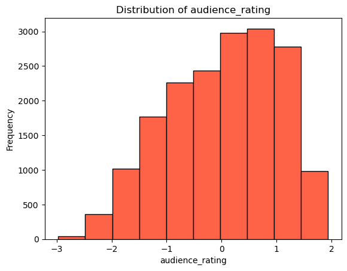

```python
# Distribution of audience_rating
plt.hist(movies_df['audience_rating'], bins=10, color='tomato', edgecolor='black')
plt.xlabel('audience_rating')
plt.ylabel('Frequency')
plt.title('Distribution of audience_rating')
plt.show()
```

**This is a normally distributed histogram skewed to the left.**

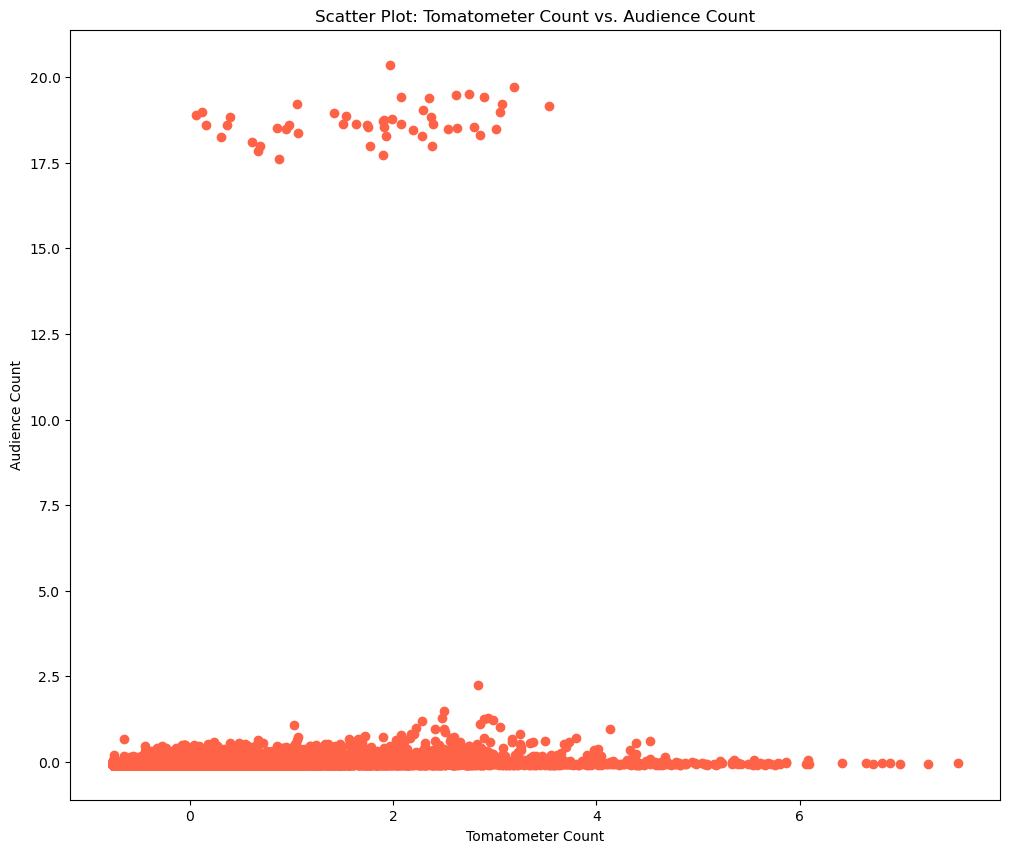

```python
# Scatter Plot between tomatometer_count and audience_count

plt.figure(figsize=(12, 10))

plt.scatter(movies_df['tomatometer_count'], movies_df['audience_count'], color='tomato', marker='o')

# Add labels and title
plt.xlabel('Tomatometer Count')
plt.ylabel('Audience Count')
plt.title('Scatter Plot: Tomatometer Count vs. Audience Count')

# Show the plot
plt.show()
```

**We can observe a floor effect on the data I assume it is due to the data having a limited range, we can also observe a small amount of outliers.**

## Multinomial Logit

```python
# MLE using packege
p_logit=sm.MNLogit(movies_df['tomatometer_status'], movies_df[['intercept', 'tomatometer_count', 'audience_rating', 'audience_count']]).fit()
p_logit.summary()
```

```
Optimization terminated successfully.
         Current function value: 0.501130
         Iterations 6
```

MNLogit Regression Results

| Dep. Variable: | tomatometer_status | No. Observations: | 17668 |
| --- | --- | --- | --- |
| Model: | MNLogit | Df Residuals: | 17664 |
| Method: | MLE | Df Model: | 3 |
| Date: | Fri, 15 Dec 2023 | Pseudo R-squ.: | 0.2661 |
| Time: | 01:55:42 | Log-Likelihood: | -8854.0 |
| converged: | True | LL-Null: | -12064. |
| Covariance Type: | nonrobust | LLR p-value: | 0.000 |

| tomatometer_status=1 | coef | std err | z | P>\|z\| | [0.025 | 0.975] |
| --- | --- | --- | --- | --- | --- | --- |
| intercept | 0.3772 | 0.019 | 20.233 | 0.000 | 0.341 | 0.414 |
| tomatometer_count | -0.0443 | 0.019 | -2.337 | 0.019 | -0.082 | -0.007 |
| audience_rating | 1.5164 | 0.023 | 64.641 | 0.000 | 1.470 | 1.562 |
| audience_count | 0.0011 | 0.017 | 0.064 | 0.949 | -0.033 | 0.035 |

```python
# Now i will change my data into numpy array since i will show a coded Multinomial Logit

df_m = np.array(movies_df[['intercept', 'tomatometer_count', 'audience_count', 'audience_rating', 'tomatometer_status']])
df_m
```

```
array([[ 1.        ,  1.34361176,  0.06305888, -0.37067002,  0.        ],
       [ 1.        ,  1.24122485, -0.07564333,  0.16892266,  1.        ],
       [ 1.        , -0.48472599, -0.07386705, -0.37067002,  1.        ],
       ...,
       [ 1.        , -0.68949982, -0.07817238,  1.24810801,  1.        ],
       [ 1.        , -0.49935269, -0.06500907,  1.49337741,  1.        ],
       [ 1.        , -0.71875322, -0.07970135,  0.0708149 ,  0.        ]])
```

```python
# Coded MLE
# Write the sigmoid
@jit
def sigmoid(data, beta):

    Xb = np.dot(data, beta)

    eXb = np.exp(Xb)
    eXb = eXb /eXb.sum(1)[:, None]
    return eXb
```

```python
# log likelihood function for multinomial logit
@jit

def LogL(params, *args):
    y, X, n_params, n_classes = args[0], args[1], args[2], args[3]
    beta = params

    beta = np.array(beta).reshape(n_params, -1, order='F') #Reshape so the elements can be multipled correctly.

    beta[:,0] = [0]*n_params #This is so only J-1 parameter sets are fitted.

    d = pd.get_dummies(y).to_numpy()

    probs = sigmoid(X, beta)
    logged = np.log(probs)
    ll = d * logged

    return -np.sum(ll)
```

```python
# Define parameters and starting values
n_params = 4
n_classes = 2

starting_values = np.random.rand(n_params*n_classes)

# Optimize
optimize.minimize(LogL, x0 = starting_values, args = (df_m[:, -1], df_m[:, :-1], n_params, n_classes))
```

```
  message: Optimization terminated successfully.
  success: True
   status: 0
      fun: 8853.957838393313
        x: [ 7.808e-01  6.204e-01  4.722e-02  2.690e-01  3.772e-01
            -4.434e-02  1.097e-03  1.516e+00]
      nit: 14
      jac: [ 0.000e+00  0.000e+00  0.000e+00  0.000e+00  0.000e+00
             0.000e+00  0.000e+00  0.000e+00]
 hess_inv: [[ 1.000e+00  0.000e+00 ...  0.000e+00  0.000e+00]
            [ 0.000e+00  1.000e+00 ...  0.000e+00  0.000e+00]
            ...
            [ 0.000e+00  0.000e+00 ...  2.840e-04  4.325e-06]
            [ 0.000e+00  0.000e+00 ...  4.325e-06  5.919e-04]]
     nfev: 216
     njev: 24
```

**We can observe similar coefficients to the optimization using the package.**

*Note:* *The first time I tried it it worked however I got a message that said 'Desired error not necessarily achieved due to precision loss.' So I decided to use @jit to see if making it faster would help and it did and was terminated successfully.*

```python
# Calculate marginal effects
p_logit.get_margeff(at='mean').summary()
```

MNLogit Marginal Effects

| Dep. Variable: | tomatometer_status |
| --- | --- |
| Method: | dydx |
| At: | mean |

| tomatometer_status=0 | dy/dx | std err | z | P>\|z\| | [0.025 | 0.975] |
| --- | --- | --- | --- | --- | --- | --- |
| tomatometer_count | 0.0107 | 0.005 | 2.337 | 0.019 | 0.002 | 0.020 |
| audience_rating | -0.3659 | 0.006 | -64.549 | 0.000 | -0.377 | -0.355 |
| audience_count | -0.0003 | 0.004 | -0.064 | 0.949 | -0.008 | 0.008 |
| tomatometer_status=1 | dy/dx | std err | z | P>\|z\| | [0.025 | 0.975] |
| tomatometer_count | -0.0107 | 0.005 | -2.337 | 0.019 | -0.020 | -0.002 |
| audience_rating | 0.3659 | 0.006 | 64.549 | 0.000 | 0.355 | 0.377 |
| audience_count | 0.0003 | 0.004 | 0.064 | 0.949 | -0.008 | 0.008 |

## Interpretation

### tomatometer_status=0 (Rotten):

**tomatometer_count:**

- A one-unit increase in tomatometer_count will result in a **0.0107** increase in the probability of the movie being predicted as rotten.
- Z-score is significant at the 0.05 level with value **0.019** which means the effect of tomatometer is statistically significant.
- The 95% confidence iterval ranges from 0.002 to 0.020.

**audience_rating:**

- A one-unit increase in audience_rating will result in a **-0.3659** decrease in the probability of the movie being predicted as rotten.
- Z-score is highly significant at the 0.05 level with value **0.0001** which means the effect of audience_rating is statistically significant at a high level.
- The 95% confidence interval ranges from -0.377 to -0.355.

**audience_count:**

- A one-unit increase in audience_count will result in a **-0.0003** decrease in the probability of the movie being predicted as rotten.
- Z-score is not significant at the 0.05 level vith value **0.949** which means it doest really afects the dependent variable.

### tomatometer_status=1 (Fresh):

**tomatometer_count:**

- A one-unit increase in tomatometer_count will result in a **-0.0107** decrease in the probability of the movie being predicted as fresh.
- Z-score is significant at the 0,05 lever vith value **0.019** which means that the effect of tomatometer_count is statistically significant.
- The 95% confidence interval ranges from -0.020 to -0.002.

**audience_rating**

- A one-unit increase in audience_rating will result in a **0.3659** increase in the probability of the movie being predicted as fresh.
- Z-score is highly significant at a 0.05 level with value **0.0001** which means the effect of audience_rating is statistically significant at a high level.

**audience_count**

- A one-unit increase in audience_count will result in a **0.0003** increase in the probability of the movie being predicted as fresh.
- Z-score is not significant at the 0.05 level vith value **0.949** which means it doest really afects the dependent variable.

### Insights

- If there is a large number of critics reviewing a movie the probability of it being rotten increases.
- If the audience gives good reviews the chance of the movie being classified as rotten decreases.
- The amount of reviews given by the audience doesn’t impact whether a movie is classified as rotten or fresh.

*Note: only the critics classify the movies as rotten or fresh*

## Conclusions

In this project, I explored how the variables tomatometer_count, audience_rating, and audience_count influence predicting whether a movie is fresh or rotten on Rotten Tomatoes. Surprisingly, audience_count didn't seem to influence the prediction, contrary to my expectations. During this project I faced challenges with the scatterplot and data conversion, where 'rotten' and 'fresh' turned into true and false instead of 1 and 0. However, I was able to find a solution.  
Overall, the project was insightful and allowed me to work on my skills in maximum likelihood estimation and data manipulation, it also allowed me to understand the factors influencing a movie's rating on Rotten Tomatoes.

## References

- In this project, the MLE (Maximum Likelihood Estimation) code was obtained from materials presented in my lecture notes.
- The dataset used in this project was obtained from Kaggle and is available at the following link: https://www.kaggle.com/datasets/stefanoleone992/rotten-tomatoes-movies-and-critic-reviews-dataset